# Tesis - Exploracion, Analisis, calibracion y prediccion de serie de tiempo con el metodo Box-Jenkins(SARIMA)

# ===============================

## Identificacion del Modelo (METODOLOGIA BOX JENKINS)

```r
#grafica de la serie dhora
dygraph(dhora, main =
          "Horas de trabajo de maquinaria agricola de la Municipalidad de Caracoto
        con una diferencia",xlab = "year",ylab = "Horas")%>%
  dyOptions(fillGraph = TRUE, fillAlpha = 0.4)%>%
  dyOptions(drawPoints = TRUE,pointSize = 2)%>%
  dyRangeSelector()
```

[interactive chart not shown]

```r
# En el grafico de la serie con una diferencia se observa que la serie no tiene tendencia en media y en varianza; ahora se tiene que probar que la serie no tenga raiz unitaria (serie estacionaria).
```

### TEST DE Dickey-Fuller PARA VER SI LOS RESIDUALES TIENEN RAIZ UNITARIA

```r
adf.test(dhora,alternative = "stationary")
```

```
##
##  Augmented Dickey-Fuller Test
##
## data:  dhora
## Dickey-Fuller = -9.4505, Lag order = 4, p-value = 0.01
## alternative hypothesis: stationary
```

```r
# se tiene que el valor-P 0.01 el cual es menor al nivel de significancia 0.05. Por lo tanto, indica que se rechaza la hipotesis nula H_0 y se acepta la hipotesis alterna H_1 quiere decir, que los datos de la serie con una diferencia de horas de trabajo de las maquinarias de la municipalidad de Caracoto no presentan raiz unitaria por lo cual la serie es estacionaria.
```

# ===============================

## ESTIMACION DEL MODELO

#### APLICAMOS AUTO-ARIMA A LA SERIE CON UNA DIFERENCIAS Y GRAFICAMOS LA AUTOCORRELACION Y AUTOCORRELACION PARCIAL

```r
auto.arima(dhora, trace=TRUE)
```

```
##
##  ARIMA(2,0,2)(1,1,1)[12] with drift         : Inf
##  ARIMA(0,0,0)(0,1,0)[12] with drift         : 1032.429
##  ARIMA(1,0,0)(1,1,0)[12] with drift         : 1011.343
##  ARIMA(0,0,1)(0,1,1)[12] with drift         : Inf
##  ARIMA(0,0,0)(0,1,0)[12]                    : 1030.377
##  ARIMA(1,0,0)(0,1,0)[12] with drift         : 1009.453
##  ARIMA(1,0,0)(0,1,1)[12] with drift         : 1011.373
##  ARIMA(1,0,0)(1,1,1)[12] with drift         : 1013.236
##  ARIMA(2,0,0)(0,1,0)[12] with drift         : 1000.839
##  ARIMA(2,0,0)(1,1,0)[12] with drift         : 1002.837
##  ARIMA(2,0,0)(0,1,1)[12] with drift         : 1002.886
##  ARIMA(2,0,0)(1,1,1)[12] with drift         : 1004.207
##  ARIMA(3,0,0)(0,1,0)[12] with drift         : 997.6634
##  ARIMA(3,0,0)(1,1,0)[12] with drift         : 999.4645
##  ARIMA(3,0,0)(0,1,1)[12] with drift         : 999.5566
##  ARIMA(3,0,0)(1,1,1)[12] with drift         : 1000.894
##  ARIMA(4,0,0)(0,1,0)[12] with drift         : 998.2301
##  ARIMA(3,0,1)(0,1,0)[12] with drift         : Inf
##  ARIMA(2,0,1)(0,1,0)[12] with drift         : Inf
##  ARIMA(4,0,1)(0,1,0)[12] with drift         : Inf
##  ARIMA(3,0,0)(0,1,0)[12]                    : 995.566
##  ARIMA(3,0,0)(1,1,0)[12]                    : 997.317
##  ARIMA(3,0,0)(0,1,1)[12]                    : 997.4107
##  ARIMA(3,0,0)(1,1,1)[12]                    : 998.686
##  ARIMA(2,0,0)(0,1,0)[12]                    : 998.7515
##  ARIMA(4,0,0)(0,1,0)[12]                    : 996.1103
##  ARIMA(3,0,1)(0,1,0)[12]                    : 976.5267
##  ARIMA(3,0,1)(1,1,0)[12]                    : 978.3886
##  ARIMA(3,0,1)(0,1,1)[12]                    : 978.4742
##  ARIMA(3,0,1)(1,1,1)[12]                    : 979.7282
##  ARIMA(2,0,1)(0,1,0)[12]                    : 974.5072
##  ARIMA(2,0,1)(1,1,0)[12]                    : 976.2285
##  ARIMA(2,0,1)(0,1,1)[12]                    : 976.3348
##  ARIMA(2,0,1)(1,1,1)[12]                    : 977.4523
##  ARIMA(1,0,1)(0,1,0)[12]                    : 972.4447
##  ARIMA(1,0,1)(1,1,0)[12]                    : 974.2743
##  ARIMA(1,0,1)(0,1,1)[12]                    : 974.3418
##  ARIMA(1,0,1)(1,1,1)[12]                    : Inf
##  ARIMA(0,0,1)(0,1,0)[12]                    : 970.5358
##  ARIMA(0,0,1)(1,1,0)[12]                    : 972.3239
##  ARIMA(0,0,1)(0,1,1)[12]                    : 972.3964
##  ARIMA(0,0,1)(1,1,1)[12]                    : 973.369
##  ARIMA(0,0,2)(0,1,0)[12]                    : 972.4322
##  ARIMA(1,0,0)(0,1,0)[12]                    : 1007.377
##  ARIMA(1,0,2)(0,1,0)[12]                    : Inf
##  ARIMA(0,0,1)(0,1,0)[12] with drift         : Inf
##
##  Best model: ARIMA(0,0,1)(0,1,0)[12]
```

```
## Series: dhora
## ARIMA(0,0,1)(0,1,0)[12]
##
## Coefficients:
##           ma1
##       -0.9487
## s.e.   0.0348
##
## sigma^2 estimated as 483.9:  log likelihood=-483.21
## AIC=970.42   AICc=970.54   BIC=975.77
```

```r
# el mejor modelo generado por AUTO - ARIMA es un SARIMA(0,0,1)(0,1,0)[12]; de la serie con una diferencia.

par(mfrow=c(2,1), mar=c(4,4,4,1+.1))
```

### GRAFICA DE AUTOCORRELACION SIMPLE Y AUTOCORRELACION PARCIAL

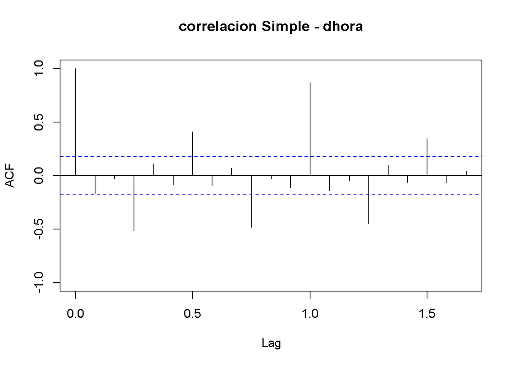

```r
#dividir el cuadro para las graficas
acf(dhora, main="correlacion Simple - dhora",
    ylim=c(-1,1),col="black")
```

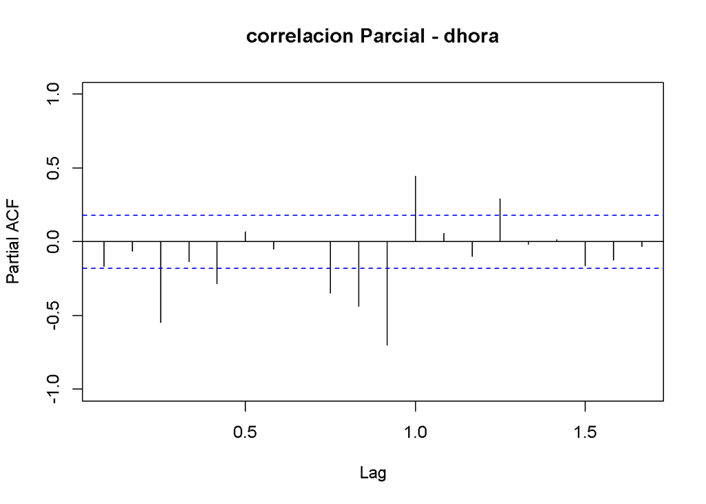

```r
pacf(dhora, main="correlacion Parcial - dhora",
     ylim=c(-1,1),col="black")
```

##### Los modelos calculados por auto.arima los guardamos en una tabla de datos para calcular los ECM y selecionar el modelo que tiene menor error cuadratico medio

# ===============================

### PARA CALIBRAMOS LOS MODELOS ENCONTRADOS POR AUTO-ARIMA PARTICIONAMOS LA SERIE EN DOS GRUPOS:

#### Aprendizaje cera del 2010 al 2018 y testin del 2019

### PARTICION DE LOS DATOS DE LA SERIE HORA

```r
ahora <- dhora[1:107]
#Serie de arpender
ahora <- ts(ahora, start =c(2010,2), freq = 12)
ahora
```

```
##       Jan  Feb  Mar  Apr  May  Jun  Jul  Aug  Sep  Oct  Nov  Dec
## 2010        11   69  -13  117  -43   13 -148   64   97    9 -120
## 2011  -62   13   75   -7  108 -103   62 -112   54  126  -24 -134
## 2012  -56   13   55   12   89  -89   66 -110   73  171  -84 -140
## 2013  -56   13   53   32   75  -83   68 -122   79  183  -68 -170
## 2014  -50   11   57   35   71  -84   58 -120  208   87  -73 -200
## 2015  -56   13   43   80   54  -88   78 -140  176  120  -35 -235
## 2016  -64   11   59   68   80 -112  112 -170  186  114  -14 -280
## 2017  -22  -17   61   34  170 -162   94 -150  177   96   45 -334
## 2018  -30    1   93   22  165 -163  102 -168  191  106   -5 -284
```

```r
length(ahora)
```

```
## [1] 107
```

```r
#serie de testin
thora <- dhora[108:119]
thora
```

```
##  [1]  -40  -15  119    5  172 -166  109 -174  208  110  -34 -251
```

```r
length(thora)
```

```
## [1] 12
```

### CALIBRANDO EL MODELOS CON LOS DATOS DE APRENDISAJE Y TESTIN

```r
# Para encontrar el mejor modelo, calibraremos los modelos propuesto por Auto-arima y los mediremos con el Error Cuadratico Medio (ECM); y elegimos al modelo que tenga el menor ECM.
```

### MEDICION DEL ERROR EN PRONOSTICOS DE SERIES

```r
#ERROR RELATIVO (ER)
ER <- function(Pron, Real){
  return(sum(abs(Pron-Real))/abs(sum(Real)))
}
#ERROR CUADRATICO MEDIO (MSE)
ECM <- function(Pred, Real){
  N <- length(Real)
  SS <- sum((Real-Pred)^2)
  return(1/N*SS)
}
# PORCENTAJE DE FALLAS HACIA ARRIBA EN CONTEO (PFA)
PFA <- function(Pron, Real){
  Total <- 0
  N <- length(Pron)
  for(i in 1:N){
    if (Pron[i]>=Real[i])
      Total <- Total+1
  }
  return(Total/N)
}
# PORCENTAJE DE FALLAS HACIA ARRIBA EN ABSOLUTO (PTFA)
PTFA <- function(Pron, Real){
  Total <- 0
  SReal <- 0
  N <- length(Pron)
  for (i in 1:N) {
    if (Pron[i] >= Real[i]) {
      Total<-Total+(Pron[i]-Real[i])
      SReal<-SReal+abs(Real[i])
    }
  }
  if(Total==0)
    SReal = 1
  return(Total/SReal)
}
```

#### Calibracion de modelos que fueron propuesto por Auto-arima de la serie con primera diferencia y los calibramos con el Grupo aprendizaje

```r
tmod<-read.csv("modelos.csv",header = T, dec=".", sep=";")
head(tmod)
```

```
##   Mumero metodo ar de ma sra sde sma ped  con derivada      aic
## 1      1  ARIMA  0  0  0   0   1   0  12 with    drift 1032.429
## 2      2  ARIMA  1  0  0   1   1   0  12 with    drift 1011.343
## 3      3  ARIMA  0  0  0   0   1   0  12    :          1030.377
## 4      4  ARIMA  1  0  0   0   1   0  12 with    drift 1009.453
## 5      5  ARIMA  1  0  0   0   1   1  12 with    drift 1011.373
## 6      6  ARIMA  1  0  0   1   1   1  12 with    drift 1013.236
```

```r
# Funcion para calibrar los modelos
calibrar<-function(aprender,testing){
  error.c<-Inf
        p<-1
            while(p<=38) {
              mod.hora <- arima(x = aprender, order = c(tmod[p,3],tmod[p,4],tmod[p,5]),seasonal=list(order=c(tmod[p,6],tmod[p,7],tmod[p,8]),period=12))
              pred.hora <- predict(mod.hora, n.ahead=12)
# CUADRO DE LOS ERRORES CUADRATICOS MEDIOS DE LOS MODELOS CALIBRADOS
              ecm.a <- sqrt(ECM(pred.hora$pred,testing))
              if(ecm.a<error.c){
                error.c<-ecm.a
                mejor<-mod.hora
              }
              errores<-print(paste(p,ecm.a,sep ="  =  "))
              p<-p + 1
            }
  return(mejor)
}
modelo<-calibrar(ahora,thora)
```

```
## [1] "1  =  17.5570498660794"
## [1] "2  =  20.9822464718955"
## [1] "3  =  17.5570498660794"
## [1] "4  =  19.508332625587"
## [1] "5  =  20.6517679456868"
## [1] "6  =  22.3557314507993"
## [1] "7  =  15.9109833314192"
## [1] "8  =  15.6499191419712"
## [1] "9  =  15.715324655681"
## [1] "10  =  15.2407393959267"
## [1] "11  =  18.8529456010216"
## [1] "12  =  18.2163496658451"
## [1] "13  =  18.3636504032046"
## [1] "14  =  18.1818377969214"
## [1] "15  =  17.792929647429"
```

[output cut: 23 more lines]

```r
modelo
```

```
##
## Call:
## arima(x = aprender, order = c(tmod[p, 3], tmod[p, 4], tmod[p, 5]), seasonal = list(order = c(tmod[p,
##     6], tmod[p, 7], tmod[p, 8]), period = 12))
##
## Coefficients:
##           ar1      ar2    sar1     sma1
##       -0.6010  -0.3241  0.7466  -0.6768
## s.e.   0.0998   0.1036  0.4390   0.4730
##
## sigma^2 estimated as 677.9:  log likelihood = -444.8,  aic = 899.6
```

```r
# El mejor modelo calibrado por la funci?n programa es
# SARIMA(2,0,0)(1,1,1)[12]; el cual obtuvo el menor ECM de 15.2407393959267.
```

# ===============================

## IDENTIFICACION DEL MODELO A UTILIZAR

#### CALCULAMOS LAS MEDICIONES DE ERRORES EN PRONOSTICO DE LOS MODELOS PROPUESTOS:

#### Modelo SARIMA(0,1,1)(0,1,0)[12]

```r
# Se obtuvo aplicando Auto-arima a la sarie con una diferencia
```

```r
#   SERIE ahora SARIMA(0,1,1)(0,1,0)[12]
mod.ahora <- arima(x = ahora, order = c(0,1,1),seasonal=list(order=c(0,1,0),period=12))
mod.ahora
```

```
##
## Call:
## arima(x = ahora, order = c(0, 1, 1), seasonal = list(order = c(0, 1, 0), period = 12))
##
## Coefficients:
##           ma1
##       -1.0000
## s.e.   0.0263
##
## sigma^2 estimated as 955.1:  log likelihood = -458.16,  aic = 920.32
```

```r
pred.ahora <- predict(mod.ahora, n.ahead=12)
pred.ahora
```

```
## $pred
##              Jan         Feb         Mar         Apr         May         Jun
## 2019  -29.621054    1.378946   93.378946   22.378946  165.378946 -162.621054
##              Jul         Aug         Sep         Oct         Nov         Dec
## 2019  102.378946 -167.621054  191.378946  106.378946   -4.621054 -283.621054
##
## $se
##          Jan     Feb     Mar     Apr     May     Jun     Jul     Aug     Sep
## 2019 31.0664 31.0664 31.0664 31.0664 31.0664 31.0664 31.0664 31.0664 31.0664
##          Oct     Nov     Dec
## 2019 31.0664 31.0664 31.0664
```

```r
#ERROR RELATIVO
er.a<-ER(pred.ahora$pred,thora)
er.a
```

```
## [1] 4.069767
```

```r
#ERROR CM
ecm.a <- sqrt(ECM(pred.ahora$pred,thora))
ecm.a
```

```
## [1] 17.53775
```

```r
#PROCENTAJE DE FALLOS ARRIBA
pfa.a<-PFA(pred.ahora$pred,thora)
pfa.a
```

```
## [1] 0.5
```

```r
#PROCENTAJE DE FALLOS ARRIBA ABSOLUTO
ptfa.a<-PTFA(pred.ahora$pred,thora)
ptfa.a
```

```
## [1] 0.1918748
```

```r
verror.a<-c(er.a,pfa.a,ptfa.a,ecm.a)
```

#### Modelo SARIMA(2,1,0)(1,1,1)[12]

```r
# Se obtubo cuando calibramos los ECM de la serie con una diferencia
```

```r
#   SERIE chora AUTO-ARIMA(2,1,0)(1,1,1)[12]
mod.chora <- arima(x = ahora, order = c(2,1,0),seasonal=list(order=c(1,1,1),period=12))
mod.chora
```

```
##
## Call:
## arima(x = ahora, order = c(2, 1, 0), seasonal = list(order = c(1, 1, 1), period = 12))
##
## Coefficients:
##           ar1      ar2     sar1    sma1
##       -0.9579  -0.4507  -0.6633  0.5738
## s.e.   0.0937   0.0935   0.6482  0.7024
##
## sigma^2 estimated as 1244:  log likelihood = -468.95,  aic = 947.91
```

```r
pred.chora <- predict(mod.chora, n.ahead=12)
pred.chora
```

```
## $pred
##              Jan         Feb         Mar         Apr         May         Jun
## 2019  -42.447337    1.146264  102.900487   17.665899  176.975811 -161.051408
##              Jul         Aug         Sep         Oct         Nov         Dec
## 2019  101.918405 -159.183706  190.173746  109.736731    7.052164 -286.873530
##
## $se
##           Jan      Feb      Mar      Apr      May      Jun      Jul      Aug
## 2019 35.27260 35.30389 39.60613 43.26255 44.52050 47.78612 49.76844 51.73478
##           Sep      Oct      Nov      Dec
## 2019 53.99909 55.80570 57.73697 59.58899
```

```r
#ERROR RELATIVO
er.c<-ER(pred.chora$pred,thora)
er.c
```

```
## [1] 4.051082
```

```r
#ERROR CM
ecm.c<-sqrt(ECM(pred.chora$pred,thora))
ecm.c
```

```
## [1] 18.91927
```

```r
#PROCENTAJE DE FALLOS ARRIBA
pfa.c<-PFA(pred.chora$pred,thora)
pfa.c
```

```
## [1] 0.5
```

```r
#PROCENTAJE DE FALLOS ARRIBA ABSOLUTO
ptfa.c<-PTFA(pred.chora$pred,thora)
ptfa.c
```

```
## [1] 0.1671467
```

```r
verror.c<-c(er.c,pfa.c,ptfa.c,ecm.c)
```

#### Modelo ARIMA(2,1,0)(0,0,0)[12]

```r
# Se planteamos como investigador cuando se observa las graficas de ACF y PACF de la serie con una diferencia
```

```r
#   SERIE ihora AUTO-ARIMA(2,1,0)(0,0,0)[12]
mod.ihora <- arima(x = ahora, order = c(2,1,0),seasonal=list(order=c(0,0,0),period=12))
mod.ihora
```

```
##
## Call:
## arima(x = ahora, order = c(2, 1, 0), seasonal = list(order = c(0, 0, 0), period = 12))
##
## Coefficients:
##           ar1      ar2
##       -0.5732  -0.0724
## s.e.   0.0991   0.0990
##
## sigma^2 estimated as 19973:  log likelihood = -675.39,  aic = 1356.79
```

```r
pred.ihora <- predict(mod.ihora, n.ahead=12)
pred.ihora
```

```
## $pred
##            Jan       Feb       Mar       Apr       May       Jun       Jul
## 2019 -116.0373 -192.1128 -160.6677 -173.1837 -168.2864 -170.1873 -169.4523
##            Aug       Sep       Oct       Nov       Dec
## 2019 -169.7360 -169.6266 -169.6687 -169.6525 -169.6587
##
## $se
##           Jan      Feb      Mar      Apr      May      Jun      Jul      Aug
## 2019 141.3264 153.6596 181.4584 198.9753 217.3826 233.4953 248.8745 263.2439
##           Sep      Oct      Nov      Dec
## 2019 276.9101 289.9176 302.3716 314.3305
```

```r
#ERROR RELATIVO
er.i<-ER(pred.ihora$pred,thora)
er.i
```

```
## [1] 51.45304
```

```r
#ERROR CM
ecm.i<-sqrt(ECM(pred.ihora$pred,thora))
ecm.i
```

```
## [1] 221.042
```

```r
#PROCENTAJE DE FALLOS ARRIBA
pfa.i<-PFA(pred.ihora$pred,thora)
pfa.i
```

```
## [1] 0.1666667
```

```r
#PROCENTAJE DE FALLOS ARRIBA ABSOLUTO
ptfa.i<-PTFA(pred.ihora$pred,thora)
ptfa.i
```

```
## [1] 0.2014242
```

```r
verror.i<-c(er.i,pfa.i,ptfa.i,ecm.i)
```

### COMPARAMOS LOS MODELOS CON EL GRAFICO DE RADAR

```r
# Cuadro de Medicion de Errores en pronosticos de series
errores<-rbind(verror.a,verror.c,verror.i)
rownames(errores)<-c("Errores Auto-arima","Errores Calibrada","Errores Planteado")
colnames(errores)<-c("Error Relativo","PFA","PTFA","Error Cuadratico Medio")
errores<-as.data.frame(errores)
maximos<-apply(errores,2, max)
minimos<-apply(errores,2, min)
errores<-rbind(minimos,errores)
errores<-rbind(maximos,errores)
errores
```

```
##                    Error Relativo       PFA      PTFA Error Cuadratico Medio
## 1                       51.453036 0.5000000 0.2014242              221.04198
## 11                       4.051082 0.1666667 0.1671467               17.53775
## Errores Auto-arima       4.069767 0.5000000 0.1918748               17.53775
## Errores Calibrada        4.051082 0.5000000 0.1671467               18.91927
## Errores Planteado       51.453036 0.1666667 0.2014242              221.04198
```

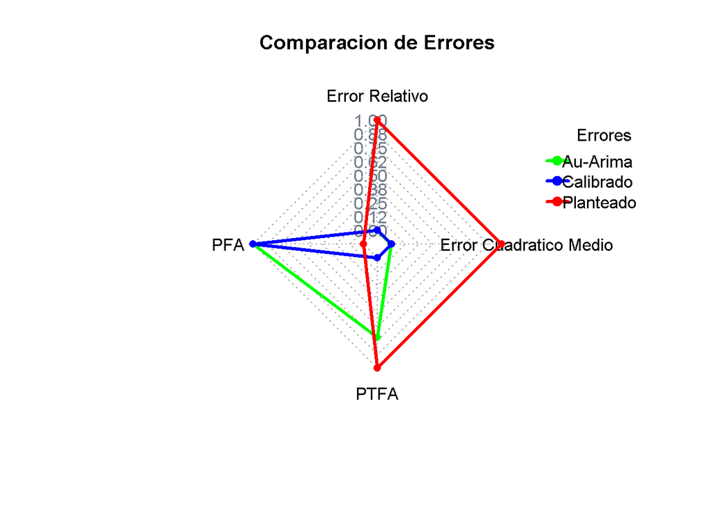

```r
# CREANDO GRAFICO DE REDAR
radarchart(errores,maxmin = TRUE,axistype = 4,axislabcol = "slategray4",
           centerzero = FALSE,seg = 8,cglcol = "gray67",
           pcol = c("green","blue","red"),
           plty = 1,
           plwd = 3,
           title = "Comparacion de Errores")
legenda<-legend(1.5,1,legend = c("Au-Arima","Calibrado","Planteado"),
                seg.len = -1.4,
                title = "Errores",
                pch = 21,
                bty = "n",lwd = 3,y.intersp = 1,horiz = FALSE,
                col = c("green","blue","red"))
```

```r
# El grafico de radar se observa que el modelo de Auto-arima y el modelo Calibrado tienen mediciones similares, a ecepcion de PTFA lo cual para elegir el menor modelo elegimos el menor PTFA que pertenece al modelo Calibrado de SARIMA(2,1,0)(1,1,1)(12.
```

# ===============================

## VALIDACION DEL MODELO

#### EL TEST DE Ljungbox PARA VER SI LA SERIE ES RUIDO BLANCO

```r
# Al llevar a cabo el modelo de pron?stico ARIMA siempre es necesario analizar el comportamiento de los residuos, en este caso nos interesa analizar si estos residuos se comportan como ruido blanco.
```

```r
#Test de Ljungbox
mejor.modelo <- arima(x = shora, order = c(2,1,0),seasonal=list(order=c(1,1,1),period=12))

retardos <- 24
P.va.Re <- c()
inter <- c()
pva<-0.05
n.corre<-rep(1:retardos,1)

for (i in 1:length(n.corre)) {
  lb<-Box.test(residuals(mejor.modelo),lag=i,type = "Ljung-Box")
  P.va.Re[i]<- lb$p.value
  if (pva<=P.va.Re[i]) {
    inter[i]<-1
  }else{
    inter[i]<-0
  }
}
df.r<-data.frame(n.corre,P.va.Re,inter)
df.r
```

```
##    n.corre     P.va.Re inter
## 1        1 0.356636151     1
## 2        2 0.232578230     1
## 3        3 0.008506413     0
## 4        4 0.017833795     0
## 5        5 0.017442219     0
## 6        6 0.013258465     0
## 7        7 0.023862161     0
## 8        8 0.040225633     0
## 9        9 0.057464429     1
## 10      10 0.027814755     0
## 11      11 0.032696915     0
## 12      12 0.045150132     0
## 13      13 0.065440286     1
## 14      14 0.037425394     0
## 15      15 0.045461832     0
## 16      16 0.032668928     0
## 17      17 0.044267794     0
## 18      18 0.049211888     0
## 19      19 0.056097294     1
## 20      20 0.068055087     1
## 21      21 0.073157783     1
## 22      22 0.093890300     1
## 23      23 0.088064961     1
## 24      24 0.093864290     1
```

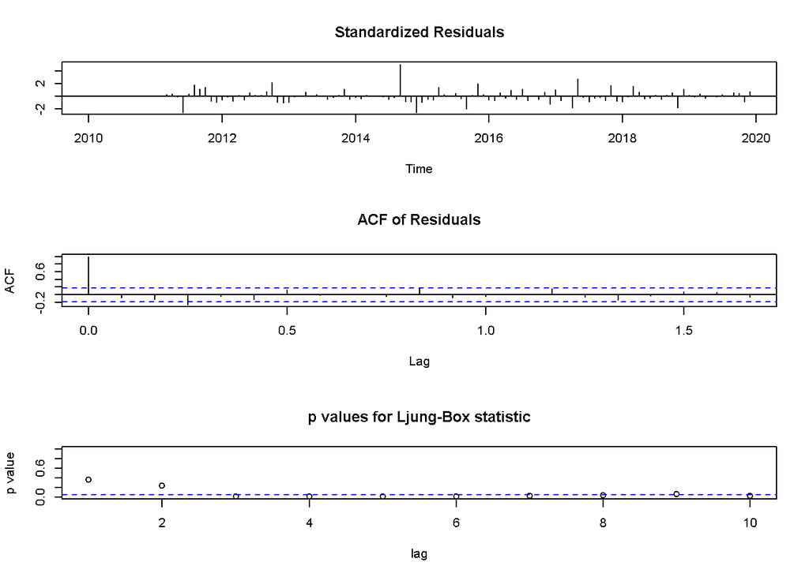

```r
tsdiag(mejor.modelo)
```

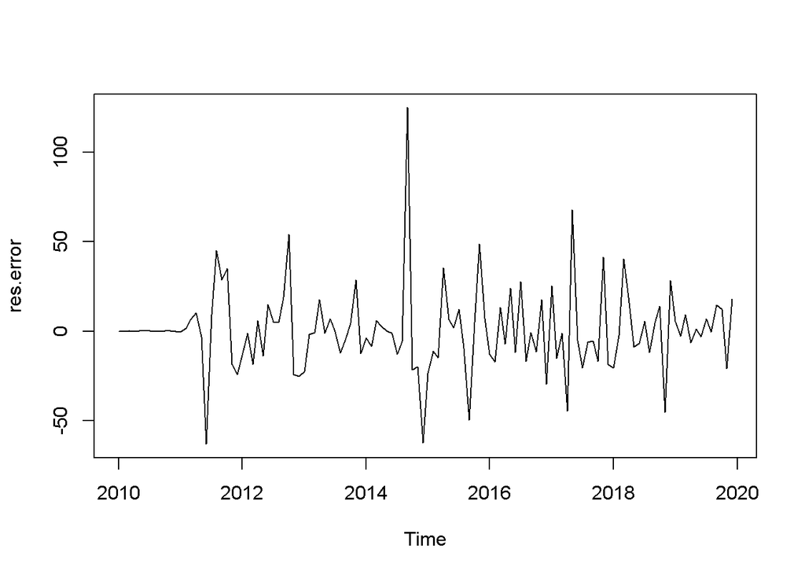

```r
res.error=residuals(mejor.modelo)
plot(res.error)
```

### LA ECUACION DEL MODELO PARA FUTURAS PREDICCIONES, MIENTRAS NO EXISTA FACTORES EXTERNOS QUE ALTEREN LA SERIE

#### Modelo:

$$SARIMA(2,1,0)(1,1,1)_{[12]}$$

#### Ecuacion del modelo:

$$Y_t=\mu+\varphi_1Y_{t-1}+\varphi_2Y_{t-2}+\varPhi_1Y_{t-12}+a_t+\Theta_1a_{t-12}$$

#### Desfase del periodo:

$"L"$ es el retardo o lag que se aplica a serie.

$$LY_t=Y_{t-1}$$
$$L^sY_t=Y_{t-s}$$

#### Igualdades:

$$\Delta Y_t=Y_t-Y_{t-1}$$
$$\nabla=(1-L)$$

#### Aplicamos la diferencias en media Regular y una(1) diferencia en media Estacional; de periodo 12:

$$\Delta^1\Delta^{12} Y_t=\varphi_1\Delta^1\Delta^{12} Y_{t-1}+\varphi_2\Delta^1\Delta^{12}Y_{t-2}+\varPhi_1\Delta^1\Delta^{12} Y_{t-12}+a_t+\Theta_1a_{t-12}$$

#### Modelo simplificado:

$$(1-\varphi_1L-\varphi_2L^2)*(1-\varPhi_1L^{12})*(1-L^1)*(1-L^{12})*Y_t=(1+\Theta_1L^{12})*a_t$$

#### Modelos reducido:

$$\varphi_2(L)*\varPhi_1(L)*\nabla^1*\nabla^{12}*Y_t=\Theta_1(L)*a_t$$

$$AR(2)*SAR(1)*(d)^1*(D)^1*Y_t=SMA(1)*a_t$$

# ===============================

# PRONOSTICO CON EL MODELO ESTIMADO

### REALIZAMOS LA PREDICCION PARA LOS SIGUIENTES 12 MESES DEL 2020 CON SU RESPECTIVA GRAFICA CON EL MODELO SARIMA(2,1,0)(1,1,1)[12]

```r
#   PREDICCION
#  Analis con los 10 year y prediccion con el modelo SARIMA(2,1,0)(1,1,1)[12]
prediccion<-forecast::forecast(mejor.modelo, h=12)
prediccion
```

```
##          Point Forecast     Lo 80    Hi 80     Lo 95    Hi 95
## Jan 2020       83.89125  52.11985 115.6627  35.30109 132.4814
## Feb 2020       62.68307  28.59414  96.7720  10.54856 114.8176
## Mar 2020      192.43076 155.80792 229.0536 136.42095 248.4406
## Apr 2020      192.30438 150.87110 233.7377 128.93765 255.6711
## May 2020      366.68141 322.49129 410.8715 299.09845 434.2644
## Jun 2020      199.71209 152.79126 246.6329 127.95286 271.4713
## Jul 2020      309.46975 259.60091 359.3386 233.20195 385.7376
## Aug 2020      133.80520  81.41147 186.1989  53.67590 213.9345
## Sep 2020      344.64246 289.80425 399.4807 260.77465 428.5103
## Oct 2020      454.67224 397.43517 511.9093 367.13570 542.2088
## Nov 2020      417.99797 358.50457 477.4914 327.01066 508.9853
## Dec 2020      169.34412 107.66844 231.0198  75.01931 263.6689
```

$$=====================$$

#### Ecuacion del modelo con sus coeficientes:

$$(1-L^1)(1-L^{12})Y_t=(1-0.6111L-0.3410L^2)(1-0.6738L^{12})(1+0.5878L^{12})a_t$$
$$=====================$$

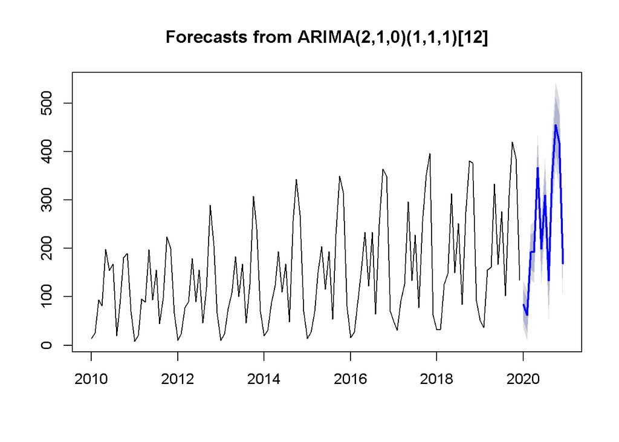

```r
plot(prediccion)
```

```r
pred <- predict(mejor.modelo,n.ahead = 12)

preds<-pred$pred
LimInf<-preds-pred$se

LimSup<-preds+pred$se

per_1<-seq(as.Date("2010-1-1"),as.Date("2019-12-1"),"month")
per_2<-seq(as.Date("2020-1-1"),as.Date("2020-12-1"),"month")

todas.series<-cbind(shora=xts(shora,order.by=per_1),LimInf=xts(LimInf,order.by=per_2),Pronostico=xts(preds,order.by=per_2),LimSup=xts(LimSup,order.by=per_2))

dygraph(todas.series,main = "Prediccion de horas mensuales para el año 2020",xlab="Año",ylab="Cantidad de horas")%>%
  dyOptions(fillGraph = TRUE, fillAlpha = 0.4)%>%
  dyOptions(drawPoints = TRUE,pointSize = 2)%>%
  dySeries(c("LimInf","Pronostico","LimSup"),label = "Horas")%>%
  dyRangeSelector(height = 20,strokeColor = "")%>%
  dyOptions(axisLineColor = "navy",gridLineColor = 'lightblue')
```

[interactive chart not shown]